# Introduction to humapr

Benjamin Skov Kaas-Hansen

2020-04-14

This vignette gives a quick and dirty introduction to `humapr`. Built on `ggplot2`, it’s not all that difficult to use, and we strive to keep the quirks to a minimum. This vignette features only customisation with standard `ggplot2` functions.

This first version of humapr is simple: you initiate things with `humap()`, basically creating an empty `ggplot` object with appropriate theme settings, and then you add the `geom` you want to use. `humapr` currently features two geom types: a stylised body surface divided into major topographic regions, and stylised internal organs. The arguments to these are similar; I’ll show examples of both below. They is actually another geom (`geom_ais`) but I won’t get into it here.

## Getting started

`humapr` for now isn’t on available on CRAN, so using `install.packages` won’t get you far. Instead, use the `devtools` package to fetch `humapr` from GitHub where it currenly lives. If you don’t have it, run `install.packages("devtools")`.

```r
devtools::install_github("benskov/humapr")
```

## Setting up

Here we load useful packages and create a little utility function to help us create simulated data for the examples below.

```r
for (p in c("dplyr", "tibble", "humapr", "gridExtra", "grid"))
    library(p, character.only = TRUE)

sampler <- function(x, n)
    sample(x, n, TRUE, sample(seq(0.5, 1, length = length(x)), length(x), TRUE))
```

## geom_body: Major topographic regions

It shouldn’t be a big surprise that this geom maps your data onto the stylised body surface. We first create some toy data to play with:

```r
body_data <- data.frame(loc = sampler(c("head", "neck", "chest", "abdomen", "arm",
                                        "forearm", "hand", "thigh", "leg", "foot"), 200),
                        side = sampler(c("left", "right"), 200),
                        gender = sample(c("male", "female"), 200, TRUE),
                        year = 2010:2019)
```

Let’s look at top-10 rows in the toy data:

```r
head(body_data, 10)
```

```
#> # A tibble: 10 x 4
#>    loc   side  gender  year
#>    <fct> <fct> <fct>  <int>
#>  1 chest left  male    2010
#>  2 arm   left  male    2011
#>  3 foot  left  male    2012
#>  4 hand  left  female  2013
#>  5 arm   right female  2014
#>  6 leg   left  male    2015
#>  7 chest left  male    2016
#>  8 thigh left  female  2017
#>  9 arm   left  female  2018
#> 10 arm   left  male    2019
```

And now, for a simple plot. We’re not giving `humapr` any data to discriminate left- from right-side data, so regions are pooled.

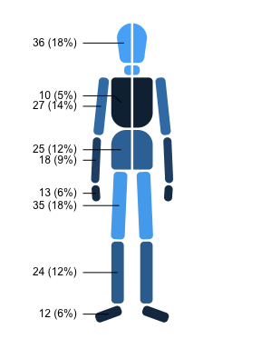

```r
humap() +
    geom_body(aes(loc = loc), body_data, combine = list(head = c("head", "neck")))
```

If we do tell `humapr` which variable in the data frame holds information on side of the observation, this is put to use without further arguments:

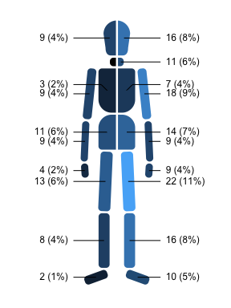

```r
humap() +
    geom_body(aes(loc = loc, side = side), body_data)
```

## geom_organs: Internal organs

Again, we create some toy data:

```r
organs <- c("urogenital", "right_kidney", "left_kidney", "pancreas", "liver", "spleen",
            "oesophagus", "stomach", "intestine", "heart", "trachea", "hyoid", "larynx",
            "right_lung", "left_lung")

organ_data <- data.frame(loc = sampler(organs, 300),
                         gender = sampler(c("Female", "Male"), 300),
                         period = sampler(c("2001-05", "2006-10"), 300))
```

Then, we make a simple tabulation plot of the observation in each organ. Because organs, generally, are not left-right symmetric, there’s no `side` argument in `geom_organs`. Instead, you assigne observations directly to, e.g., `right_lung` and `left_kidney`.

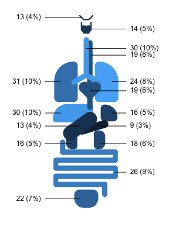

```r
humap() +
    geom_organs(aes(loc = loc), organ_data)
```

## Annotation lines and labels

By default, `humapr` puts annotation lines with absolute and relative frequency labels. You can change this with the `annotate` argument:

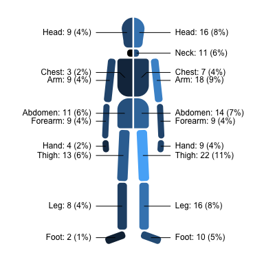

```r
humap() +
    geom_body(aes(loc = loc, side = side), body_data, annotate = "all")
```

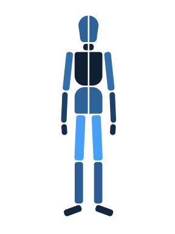

```r
humap() +
    geom_body(aes(loc = loc), body_data, annotate = NULL)
```

## Change the fill scale

`humapr` uses the default fill settings of `ggplot2`, so that low-count areas are dark, and high-count areas are light. It’s straightfrward to change this with the `scale_fill_gradient` just as to change the fill colours altogether. Here, I let low-count areas have light-grey, and high-count areas dark-green fill.

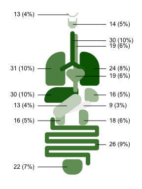

```r
humap() +
    geom_organs(aes(loc = loc), organ_data) +
    scale_fill_gradient(low = "grey95", high = "darkgreen")
```

## Facetting

Facetting is as simple as always when using `ggplot2`.

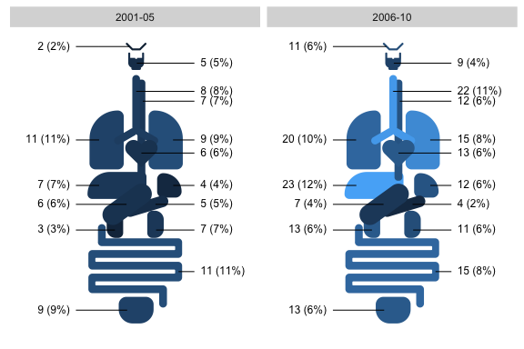

```r
humap() +
    geom_organs(aes(loc = loc), organ_data) +
    facet_wrap(~ period)
```

Beware, however, that facetting can give distorted results, because the range is shared across facets. This may be intended behaviour, but sometimes it’s better to do “stratified tabulation” and manually align plots.

Here—to give the same appearance as normal `ggplot2` facetting—I do actually use `facet_wrap` even though there is just one facetting level. It’s a slight hack, but works well. Keeping annotations here can become a bit unwieldy, so I’ve removed them in this example.

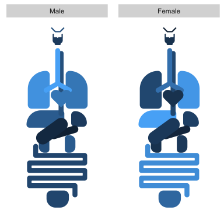

```r
males <- humap() +
    geom_organs(aes(loc = loc), filter(organ_data, gender == "Male"), annotate = NULL) +
    facet_wrap(~ gender)
females <- humap() +
    geom_organs(aes(loc = loc), filter(organ_data, gender == "Female"), annotate = NULL) +
    facet_wrap(~ gender)
grid.arrange(males, females, nrow = 1)
```